# Machine Learning Assignment 4

2026-10-27

#Imported the data set.

```r
Pharmaceuticals <- read.csv("~/Downloads/Pharmaceuticals.csv")
head(Pharmaceuticals)
```

```
##   Symbol                Name Market_Cap Beta PE_Ratio  ROE  ROA Asset_Turnover
## 1    ABT Abbott Laboratories      68.44 0.32     24.7 26.4 11.8            0.7
## 2    AGN      Allergan, Inc.       7.58 0.41     82.5 12.9  5.5            0.9
## 3    AHM        Amersham plc       6.30 0.46     20.7 14.9  7.8            0.9
## 4    AZN     AstraZeneca PLC      67.63 0.52     21.5 27.4 15.4            0.9
## 5    AVE             Aventis      47.16 0.32     20.1 21.8  7.5            0.6
## 6    BAY            Bayer AG      16.90 1.11     27.9  3.9  1.4            0.6
##   Leverage Rev_Growth Net_Profit_Margin Median_Recommendation Location Exchange
## 1     0.42       7.54              16.1          Moderate Buy       US     NYSE
## 2     0.60       9.16               5.5          Moderate Buy   CANADA     NYSE
## 3     0.27       7.05              11.2            Strong Buy       UK     NYSE
## 4     0.00      15.00              18.0         Moderate Sell       UK     NYSE
## 5     0.34      26.81              12.9          Moderate Buy   FRANCE     NYSE
## 6     0.00      -3.17               2.6                  Hold  GERMANY     NYSE
```

#I used these codes to get the size, column, names, structure and summary of a dataset.

```r
dim(Pharmaceuticals)
```

```
## [1] 21 14
```

```r
names(Pharmaceuticals)
```

```
##  [1] "Symbol"                "Name"                  "Market_Cap"
##  [4] "Beta"                  "PE_Ratio"              "ROE"
##  [7] "ROA"                   "Asset_Turnover"        "Leverage"
## [10] "Rev_Growth"            "Net_Profit_Margin"     "Median_Recommendation"
## [13] "Location"              "Exchange"
```

```r
str(Pharmaceuticals)
```

```
## 'data.frame':    21 obs. of  14 variables:
##  $ Symbol               : chr  "ABT" "AGN" "AHM" "AZN" ...
##  $ Name                 : chr  "Abbott Laboratories" "Allergan, Inc." "Amersham plc" "AstraZeneca PLC" ...
##  $ Market_Cap           : num  68.44 7.58 6.3 67.63 47.16 ...
##  $ Beta                 : num  0.32 0.41 0.46 0.52 0.32 1.11 0.5 0.85 1.08 0.18 ...
##  $ PE_Ratio             : num  24.7 82.5 20.7 21.5 20.1 27.9 13.9 26 3.6 27.9 ...
##  $ ROE                  : num  26.4 12.9 14.9 27.4 21.8 3.9 34.8 24.1 15.1 31 ...
##  $ ROA                  : num  11.8 5.5 7.8 15.4 7.5 1.4 15.1 4.3 5.1 13.5 ...
##  $ Asset_Turnover       : num  0.7 0.9 0.9 0.9 0.6 0.6 0.9 0.6 0.3 0.6 ...
##  $ Leverage             : num  0.42 0.6 0.27 0 0.34 0 0.57 3.51 1.07 0.53 ...
##  $ Rev_Growth           : num  7.54 9.16 7.05 15 26.81 ...
##  $ Net_Profit_Margin    : num  16.1 5.5 11.2 18 12.9 2.6 20.6 7.5 13.3 23.4 ...
##  $ Median_Recommendation: chr  "Moderate Buy" "Moderate Buy" "Strong Buy" "Moderate Sell" ...
##  $ Location             : chr  "US" "CANADA" "UK" "UK" ...
##  $ Exchange             : chr  "NYSE" "NYSE" "NYSE" "NYSE" ...
```

```r
summary(Pharmaceuticals)
```

```
##        Symbol          Name      Market_Cap          Beta
##  Length   :21   Length   :21   Min.   :  0.41   Min.   :0.1800
##  N.unique :21   N.unique :21   1st Qu.:  6.30   1st Qu.:0.3500
##  N.blank  : 0   N.blank  : 0   Median : 48.19   Median :0.4600
##  Min.nchar: 3   Min.nchar: 5   Mean   : 57.65   Mean   :0.5257
##  Max.nchar: 4   Max.nchar:34   3rd Qu.: 73.84   3rd Qu.:0.6500
##                                Max.   :199.47   Max.   :1.1100
##     PE_Ratio          ROE            ROA        Asset_Turnover    Leverage
##  Min.   : 3.60   Min.   : 3.9   Min.   : 1.40   Min.   :0.3    Min.   :0.0000
##  1st Qu.:18.90   1st Qu.:14.9   1st Qu.: 5.70   1st Qu.:0.6    1st Qu.:0.1600
##  Median :21.50   Median :22.6   Median :11.20   Median :0.6    Median :0.3400
##  Mean   :25.46   Mean   :25.8   Mean   :10.51   Mean   :0.7    Mean   :0.5857
##  3rd Qu.:27.90   3rd Qu.:31.0   3rd Qu.:15.00   3rd Qu.:0.9    3rd Qu.:0.6000
##  Max.   :82.50   Max.   :62.9   Max.   :20.30   Max.   :1.1    Max.   :3.5100
##    Rev_Growth    Net_Profit_Margin Median_Recommendation      Location
##  Min.   :-3.17   Min.   : 2.6      Length   :21          Length   :21
##  1st Qu.: 6.38   1st Qu.:11.2      N.unique : 4          N.unique : 7
##  Median : 9.37   Median :16.1      N.blank  : 0          N.blank  : 0
##  Mean   :13.37   Mean   :15.7      Min.nchar: 4          Min.nchar: 2
##  3rd Qu.:21.87   3rd Qu.:21.1      Max.nchar:13          Max.nchar:11
##  Max.   :34.21   Max.   :25.5
##       Exchange
##  Length   :21
##  N.unique : 3
##  N.blank  : 0
##  Min.nchar: 4
##  Max.nchar: 6
##
```

#I am checking to see if there is missing values present.

```r
colSums(is.na(Pharmaceuticals))
```

```
##                Symbol                  Name            Market_Cap
##                     0                     0                     0
##                  Beta              PE_Ratio                   ROE
##                     0                     0                     0
##                   ROA        Asset_Turnover              Leverage
##                     0                     0                     0
##            Rev_Growth     Net_Profit_Margin Median_Recommendation
##                     0                     0                     0
##              Location              Exchange
##                     0                     0
```

#I selected the nine numerical financial variables required by the assignment to group companies with similar financial characteristics.

```r
financial_data <- Pharmaceuticals[, c(
  "Market_Cap",
  "Beta",
  "PE_Ratio",
  "ROE",
  "ROA",
  "Asset_Turnover",
  "Leverage",
  "Rev_Growth",
  "Net_Profit_Margin"
)]
head(financial_data)
```

```
##   Market_Cap Beta PE_Ratio  ROE  ROA Asset_Turnover Leverage Rev_Growth
## 1      68.44 0.32     24.7 26.4 11.8            0.7     0.42       7.54
## 2       7.58 0.41     82.5 12.9  5.5            0.9     0.60       9.16
## 3       6.30 0.46     20.7 14.9  7.8            0.9     0.27       7.05
## 4      67.63 0.52     21.5 27.4 15.4            0.9     0.00      15.00
## 5      47.16 0.32     20.1 21.8  7.5            0.6     0.34      26.81
## 6      16.90 1.11     27.9  3.9  1.4            0.6     0.00      -3.17
##   Net_Profit_Margin
## 1              16.1
## 2               5.5
## 3              11.2
## 4              18.0
## 5              12.9
## 6               2.6
```

#I standardized the nine financial variables because they are measured on different scales. Standardization gives each variable a mean of zero and a standard deviation of one, preventing variables with larger numerical scales from dominating the clustering. I gave each standardized variable equal weight.

```r
financial_scaled <- scale(financial_data)
head(financial_scaled)
```

```
##      Market_Cap        Beta    PE_Ratio         ROE        ROA Asset_Turnover
## [1,]  0.1840960 -0.80125356 -0.04671323  0.04009035  0.2416121  -5.121077e-16
## [2,] -0.8544181 -0.45070513  3.49706911 -0.85483986 -0.9422871   9.225312e-01
## [3,] -0.8762600 -0.25595600 -0.29195768 -0.72225761 -0.5100700   9.225312e-01
## [4,]  0.1702742 -0.02225704 -0.24290879  0.10638147  0.9181259   9.225312e-01
## [5,] -0.1790256 -0.80125356 -0.32874435 -0.26484883 -0.5664461  -4.612656e-01
## [6,] -0.6953818  2.27578267  0.14948233 -1.45146000 -1.7127612  -4.612656e-01
##        Leverage Rev_Growth Net_Profit_Margin
## [1,] -0.2120979 -0.5277675        0.06168225
## [2,]  0.0182843 -0.3811391       -1.55366706
## [3,] -0.4040831 -0.5721181       -0.68503583
## [4,] -0.7496565  0.1474473        0.35122600
## [5,] -0.3144900  1.2163867       -0.42597037
## [6,] -0.7496565 -1.4971443       -1.99560225
```

#I am creating an elbow plot to help decide how many clusters to use. The plot shows the sum of squares which shows how close the companies are grouped with their range. I selected three clusters because the curve begins to flatten around three. Adding more clusters provides smaller reductions in the within-cluster sum of squares.

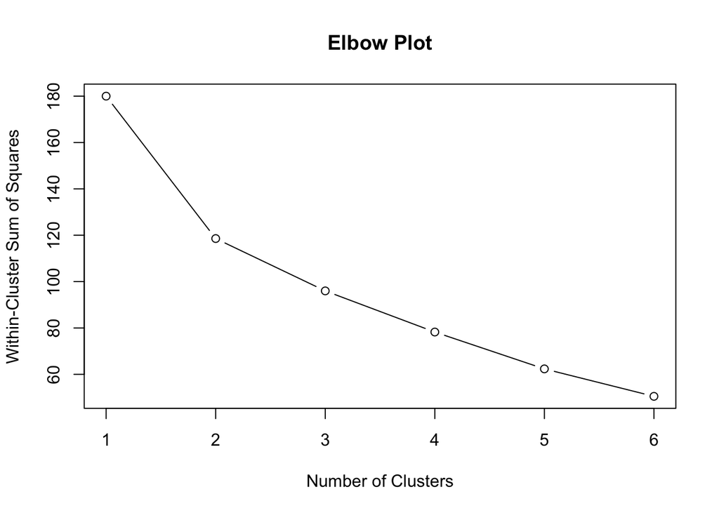

```r
set.seed(123)

wss <- numeric(6)

for (k in 1:6) {
  model <- kmeans(
    financial_scaled,
    centers = k,
    nstart = 25
  )

  wss[k] <- model$tot.withinss
}

plot(
  1:6,
  wss,
  type = "b",
  xlab = "Number of Clusters",
  ylab = "Within-Cluster Sum of Squares",
  main = "Elbow Plot"
)
```

#I am using k-means to group companies with similar financial characteristics.I used k-means to group companies with similar standardized financial characteristics by minimizing variation within clusters. I used nstart = 25 to try multiple starting configurations and set.seed(123) to make the results reproducible.

```r
set.seed(123)

pharma_clusters <- kmeans(
  financial_scaled,
  centers = 3,
  nstart = 25
)

pharma_clusters
```

```
## K-means clustering with 3 clusters of sizes 4, 11, 6
##
## Cluster means:
##   Market_Cap       Beta   PE_Ratio        ROE        ROA Asset_Turnover
## 1 -0.6125361  0.2698666  1.3143935 -0.9609057 -1.0174553      0.2306328
## 2  0.6733825 -0.3586419 -0.2763512  0.6565978  0.8344159      0.4612656
## 3 -0.8261772  0.4775991 -0.3696184 -0.5631589 -0.8514589     -0.9994088
##     Leverage Rev_Growth Net_Profit_Margin
## 1 -0.3592866 -0.5757385        -1.3784169
## 2 -0.3331068 -0.2902163         0.6823310
## 3  0.8502201  0.9158889        -0.3319956
##
## Clustering vector:
##  [1] 2 1 1 2 3 1 2 3 3 2 2 3 2 3 2 2 2 1 2 3 2
##
## Within cluster sum of squares by cluster:
## [1] 20.54199 43.30886 32.14336
##  (between_SS / total_SS =  46.7 %)
##
## Available components:
##
## [1] "cluster"      "centers"      "totss"        "withinss"     "tot.withinss"
## [6] "betweenss"    "size"         "iter"         "ifault"
```

# I am adding each company’s cluster number to the original dataset.

```r
Pharmaceuticals$Cluster <- pharma_clusters$cluster
Pharmaceuticals[, c("Name", "Symbol", "Cluster")]
```

```
##                                  Name Symbol Cluster
## 1                 Abbott Laboratories    ABT       2
## 2                      Allergan, Inc.    AGN       1
## 3                        Amersham plc    AHM       1
## 4                     AstraZeneca PLC    AZN       2
## 5                             Aventis    AVE       3
## 6                            Bayer AG    BAY       1
## 7        Bristol-Myers Squibb Company    BMY       2
## 8                        Chattem, Inc   CHTT       3
## 9               Elan Corporation, plc    ELN       3
## 10              Eli Lilly and Company    LLY       2
## 11                GlaxoSmithKline plc    GSK       2
## 12                   IVAX Corporation    IVX       3
## 13                  Johnson & Johnson    JNJ       2
## 14 Medicis Pharmaceutical Corporation    MRX       3
## 15                  Merck & Co., Inc.    MRK       2
## 16                        Novartis AG    NVS       2
## 17                         Pfizer Inc    PFE       2
## 18              Pharmacia Corporation    PHA       1
## 19        Schering-Plough Corporation    SGP       2
## 20       Watson Pharmaceuticals, Inc.    WPI       3
## 21                              Wyeth    WYE       2
```

#I am creating the clusters and counting the companies for each one.

```r
set.seed(123)
pharma_clusters <- kmeans(
  financial_scaled,
  centers = 3,
  nstart = 25
)
Pharmaceuticals$Cluster <- pharma_clusters$cluster
table(Pharmaceuticals$Cluster)
```

```
##
##  1  2  3
##  4 11  6
```

#I am finding the average financial values for each cluster and to understand what makes them different.Looking at these averages helps to see if a cluster has larger companies, more profitable companies, or companies with higher growth or leverage.

```r
cluster_averages <- aggregate(
  financial_data,
  by = list(Cluster = Pharmaceuticals$Cluster),
  FUN = mean
)
round(cluster_averages, 2)
```

```
##   Cluster Market_Cap Beta PE_Ratio  ROE   ROA Asset_Turnover Leverage
## 1       1      21.75 0.60    46.90 11.3  5.10           0.75     0.30
## 2       2      97.11 0.43    20.95 35.7 14.95           0.80     0.33
## 3       3       9.23 0.65    19.43 17.3  5.98           0.48     1.25
##   Rev_Growth Net_Profit_Margin
## 1       7.01              6.65
## 2      10.16             20.17
## 3      23.49             13.52
```

## Cluster Names and Reasoning

**Cluster 1: High P/E, Low-Profitability Companies**

This cluster contains four companies. It has the highest average P/E ratio and the lowest average ROE, ROA, and net profit margin among the three clusters.

**Cluster 2: Large, Profitable Companies**

This cluster contains eleven companies. It has the highest average market capitalization, ROE, ROA, and net profit margin, along with below-average beta and leverage.

**Cluster 3: Smaller, High-Growth, Highly Leveraged Companies**

This cluster contains six companies. It has the lowest average market capitalization and the highest average revenue growth and leverage. Its profitability is below the overall average.

#I am checking to see which companies go for each cluster.

```r
Pharmaceuticals[, c("Name", "Symbol", "Cluster")]
```

```
##                                  Name Symbol Cluster
## 1                 Abbott Laboratories    ABT       2
## 2                      Allergan, Inc.    AGN       1
## 3                        Amersham plc    AHM       1
## 4                     AstraZeneca PLC    AZN       2
## 5                             Aventis    AVE       3
## 6                            Bayer AG    BAY       1
## 7        Bristol-Myers Squibb Company    BMY       2
## 8                        Chattem, Inc   CHTT       3
## 9               Elan Corporation, plc    ELN       3
## 10              Eli Lilly and Company    LLY       2
## 11                GlaxoSmithKline plc    GSK       2
## 12                   IVAX Corporation    IVX       3
## 13                  Johnson & Johnson    JNJ       2
## 14 Medicis Pharmaceutical Corporation    MRX       3
## 15                  Merck & Co., Inc.    MRK       2
## 16                        Novartis AG    NVS       2
## 17                         Pfizer Inc    PFE       2
## 18              Pharmacia Corporation    PHA       1
## 19        Schering-Plough Corporation    SGP       2
## 20       Watson Pharmaceuticals, Inc.    WPI       3
## 21                              Wyeth    WYE       2
```

#I am checking whether brokerage recommendations differ across clusters.

```r
table(
  Pharmaceuticals$Cluster,
  Pharmaceuticals$Median_Recommendation
)
```

```
##
##     Hold Moderate Buy Moderate Sell Strong Buy
##   1    2            1             0          1
##   2    6            3             2          0
##   3    1            3             2          0
```

#Brokerage recommendations differ somewhat across the clusters. In Cluster 1, Hold is the most common recommendation, covering 2 of 4 companies (50%). This cluster also contains the only company with a Strong Buy recommendation. In Cluster 2, Hold is also most common, covering 6 of 11 companies (54.5%). In Cluster 3, Moderate Buy is most common, covering 3 of 6 companies (50%). Therefore, Clusters 1 and 2 are mainly associated with Hold recommendations, while Cluster 3 has a larger proportion of Moderate Buy recommendations.

```r
table(
  Pharmaceuticals$Cluster,
  Pharmaceuticals$Location
)
```

```
##
##     CANADA FRANCE GERMANY IRELAND SWITZERLAND UK US
##   1      1      0       1       0           0  1  1
##   2      0      0       0       0           1  2  8
##   3      0      1       0       1           0  0  4
```

```r
table(
  Pharmaceuticals$Cluster,
  Pharmaceuticals$Exchange
)
```

```
##
##     AMEX NASDAQ NYSE
##   1    0      0    4
##   2    0      0   11
##   3    1      1    4
```

#All four companies in Cluster 1 and all eleven companies in Cluster 2 are listed on the NYSE. Cluster 3 has four companies listed on the NYSE, one on AMEX, and one on NASDAQ. The NYSE is the most common exchange in every cluster, but Cluster 3 contains all the AMEX and NASDAQ companies in this dataset. Exchange therefore provides some distinction for Cluster 3, but it does not distinguish Clusters 1 and 2.